# Networks - day 1

CB

2023-02-07

# Manipulation and characterization of the networks

We first need to install the `igraph` library:

```r
#install.packages('igraph')
library(igraph)
```

After, we can create a first graph and try to manipulate it.

> Exercise: create an adjacency matrix corresponding to a undirected network where the first node is connected to the 4 other nodes, that are not connected togather.

```r
A = cbind(c(0,1,1,1,1),
          c(1,0,0,0,0),
          c(1,0,0,0,0),
          c(1,0,0,0,0),
          c(1,0,0,0,0))
```

This adjacency matrix can be used within the `igraph` environment for plots or computations.

```r
g = graph.adjacency(A)
g
```

```
## IGRAPH d5d2aae D--- 5 8 --
## + edges from d5d2aae:
## [1] 1->2 1->3 1->4 1->5 2->1 3->1 4->1 5->1
```

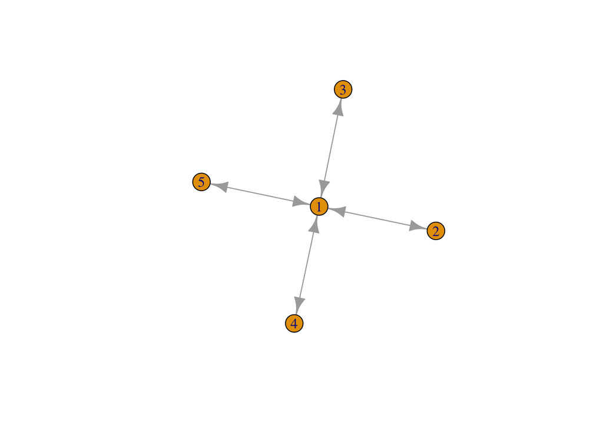

```r
plot(g)
```

If we prefer to display a undirected network, we have make this call:

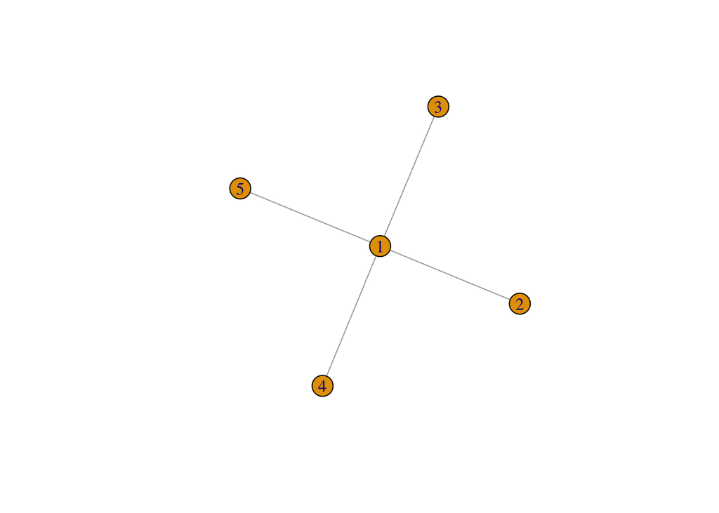

```r
g = graph.adjacency(A, mode='undirected')
plot(g)
```

> Exercise= modify the adjacendy matrix to make a connection between the nodes 3 and 5, and plot it.

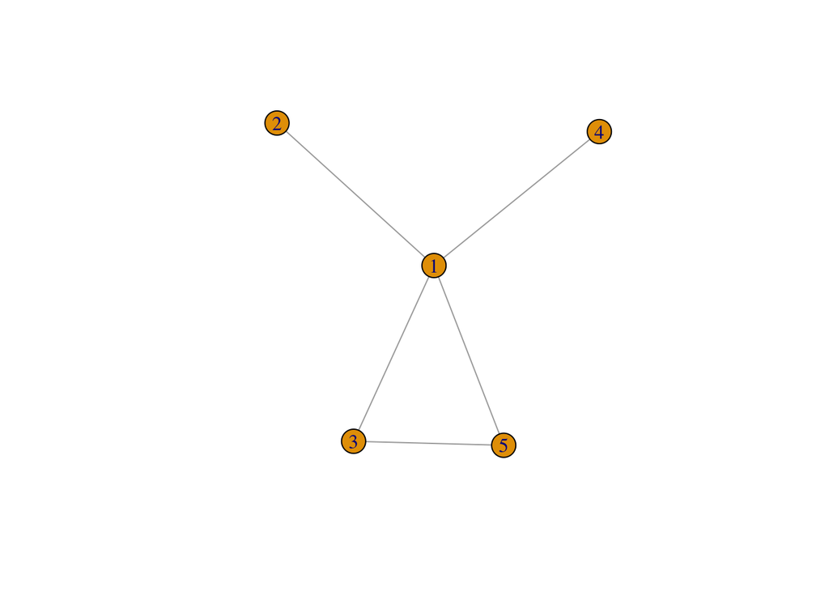

```r
A = cbind(c(0,1,1,1,1),
          c(1,0,0,0,0),
          c(1,0,0,0,1),
          c(1,0,0,0,0),
          c(1,0,1,0,0))
g = graph.adjacency(A, mode='undirected')
plot(g)
```

We can also use the `igraph` library to compute the degree of the nodes.

```r
degree(g)
```

```
## [1] 4 1 2 1 2
```

Another statistic we can compute for graphs is the number of k-cliques.

> Definition: a k-clique is a set of k nodes that are all connected togather.

For instance, in the above network, there is one 3-clique and 5 2-cliques.

```r
cliques(g)
```

```
## [[1]]
## + 1/5 vertex, from 1150621:
## [1] 1
##
## [[2]]
## + 1/5 vertex, from 1150621:
## [1] 5
##
## [[3]]
## + 2/5 vertices, from 1150621:
## [1] 1 5
##
## [[4]]
## + 1/5 vertex, from 1150621:
## [1] 4
##
## [[5]]
## + 2/5 vertices, from 1150621:
## [1] 1 4
##
## [[6]]
## + 1/5 vertex, from 1150621:
## [1] 2
##
## [[7]]
## + 2/5 vertices, from 1150621:
## [1] 1 2
##
## [[8]]
## + 1/5 vertex, from 1150621:
## [1] 3
##
## [[9]]
## + 2/5 vertices, from 1150621:
## [1] 3 5
##
## [[10]]
## + 3/5 vertices, from 1150621:
## [1] 1 3 5
##
## [[11]]
## + 2/5 vertices, from 1150621:
## [1] 1 3
```

> Exercice: write a small piece of code allowing to plot the signature of the graph by counting the number of k-cliques, k=1,…,n

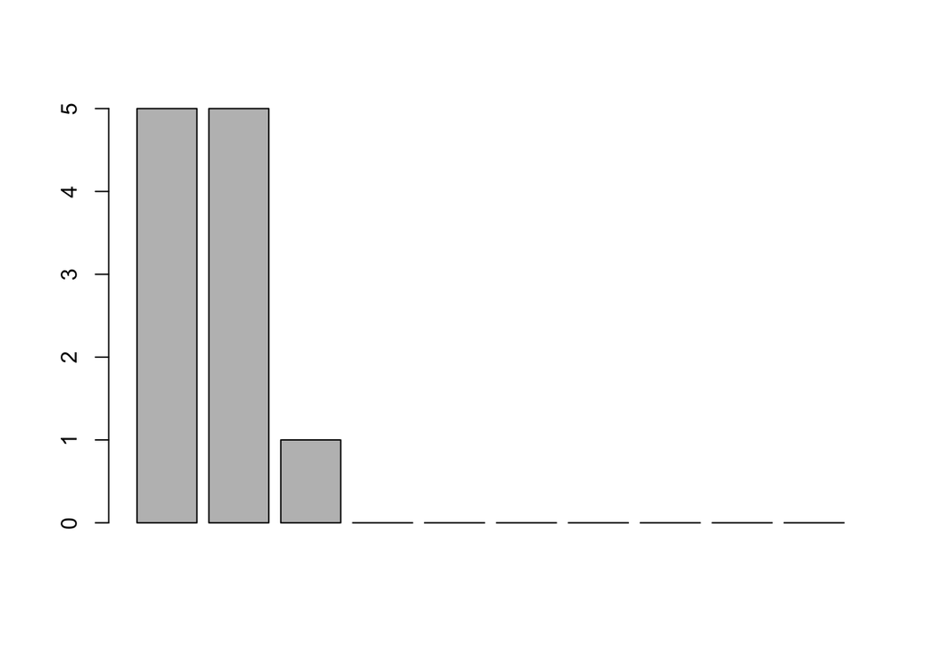

```
##  [1] 5 5 1 0 0 0 0 0 0 0
```

```r
signature <- function(g, max = 10){
   cl = cliques(g)
   s = rep(0,max)
   for (i in 1:length(cl)){
      l = length(cl[[i]])
      s[l] = s[l] + 1
   }
   barplot(s)
   return(s)
}
signature(g)
```